# Session 8: Descriptive Statistics, Models, and Tables

R Workshop for DBA Students

Author

Taikgun Song

Published

November 15, 2026

**NoteSession Objectives**

By the end of this session, you will be able to:

1. Describe data with summary statistics, cross-tabulations, and correlations
2. Explain why skewed variables are often analyzed on a log scale
3. Write model formulas: several predictors, factors, interactions, and transformations
4. Fit linear and logistic regression models with `lm()` and `glm()`, and read their output
5. Extract results from model objects with base R and `broom`
6. Build descriptive and regression tables for a paper, and render them to Word
7. Carry out a complete analysis, from raw file to report, in one Quarto document

```r
library(tidyverse)
library(broom)      # model results as data frames (installed with the tidyverse)
library(knitr)      # kable() tables (installed with Quarto and rmarkdown)
```

# 1 The Data

We build a modeling dataset from the raw finance file, using everything from Sessions 4 to 6. Models need positive revenue and market cap (for logs, Section 3) and typical net margins (Session 7 showed how a few extreme values dominate a fitted line):

```r
finance_raw <- read.csv("../data/finance_example.csv", check.names = FALSE)
names(finance_raw)[1] <- "ticker"

fin_model <- as_tibble(finance_raw) |>
  select(ticker,
         sector            = Sector,
         revenue           = Revenue,
         net_margin        = `Net Profit Margin`,
         market_cap        = `Market Cap`,
         debt_to_equity    = `Debt to Equity`,
         price_change_2015 = `2015 PRICE VAR [%]`) |>
  filter(revenue > 0, market_cap > 0, between(net_margin, -1, 1)) |>
  mutate(super_sector = case_when(
           sector %in% c("Basic Materials", "Consumer Cyclical",
                         "Financial Services", "Real Estate")           ~ "Cyclical",
           sector %in% c("Consumer Defensive", "Healthcare", "Utilities") ~ "Defensive",
           sector %in% c("Communication Services", "Energy",
                         "Industrials", "Technology")                     ~ "Sensitive"),
         super_sector = factor(super_sector),
         price_up     = if_else(price_change_2015 > 0, "Up", "Down"))

c(raw = nrow(finance_raw), modeling = nrow(fin_model))
```

```
     raw modeling
    3808     3090
```

Reporting how many observations you started with and how many you analyze is the first line of any methods section.

# 2 Descriptive Statistics

## 2.1 Summaries

`summary()` gives the quick overview; individual functions give exactly the statistic you want:

```r
summary(fin_model$net_margin)
```

```
    Min.  1st Qu.   Median     Mean  3rd Qu.     Max.
-0.97700  0.01320  0.06515  0.06962  0.15718  0.99950
```

```r
mean(fin_model$net_margin)
```

```
[1] 0.06961689
```

```r
sd(fin_model$net_margin)
```

```
[1] 0.2076113
```

```r
quantile(fin_model$net_margin, probs = c(0.10, 0.25, 0.50, 0.75, 0.90))
```

```
      10%       25%       50%       75%       90%
-0.098880  0.013200  0.065150  0.157175  0.268640
```

By group, use `group_by()` and `summarise()` from Session 5:

```r
fin_model |>
  group_by(super_sector) |>
  summarise(n             = n(),
            mean_margin   = mean(net_margin),
            sd_margin     = sd(net_margin),
            median_margin = median(net_margin))
```

```
# A tibble: 3 × 5
  super_sector     n mean_margin sd_margin median_margin
  <fct>        <int>       <dbl>     <dbl>         <dbl>
1 Cyclical      1377     0.129       0.194        0.0972
2 Defensive      500     0.00523     0.245        0.0507
3 Sensitive     1213     0.0291      0.188        0.0436
```

## 2.2 Cross-Tabulations

For two categorical variables, `table()` counts every combination, and `prop.table()` turns counts into proportions. `margin = 1` makes each **row** add up to 1:

```r
counts <- table(fin_model$super_sector, fin_model$price_up)
counts
```

```
            Down  Up
  Cyclical   689 688
  Defensive  241 259
  Sensitive  773 440
```

```r
prop.table(counts, margin = 1) |> round(3)      # share of each super sector that went up or down
```

```
             Down    Up
  Cyclical  0.500 0.500
  Defensive 0.482 0.518
  Sensitive 0.637 0.363
```

`addmargins(counts)` adds row and column totals.

## 2.3 Correlations

`cor()` measures how strongly two numeric variables move together, from -1 to 1. Given several columns, it returns a **correlation matrix**:

```r
fin_model |>
  select(revenue, market_cap, net_margin, debt_to_equity) |>
  cor(use = "complete.obs") |>                     # skip rows with missing values
  round(2)
```

```
               revenue market_cap net_margin debt_to_equity
revenue           1.00       0.01       0.01           0.00
market_cap        0.01       1.00      -0.01          -0.04
net_margin        0.01      -0.01       1.00          -0.01
debt_to_equity    0.00      -0.04      -0.01           1.00
```

`use = "complete.obs"` is needed because `debt_to_equity` has missing values; without it, every correlation involving that column is `NA`.

Look at revenue and market cap: a correlation of almost exactly **zero**. In Session 7’s scatter plot, the two were clearly related. What happened? The next section explains.

# 3 Skewed Variables and Logs

Revenue and market cap are extremely **skewed**: most firms are small, and a few are enormous. The Pearson correlation `cor()` computes is very sensitive to extreme values, and the $96 trillion firm from Session 5 alone is enough to hide the relationship.

On a **log scale**, the same data looks completely different:

```r
cor(fin_model$revenue, fin_model$market_cap)              # raw scale
```

```
[1] 0.007369615
```

```r
cor(log(fin_model$revenue), log(fin_model$market_cap))    # log scale
```

```
[1] 0.8453169
```

```r
cor(fin_model$revenue, fin_model$market_cap, method = "spearman")   # based on ranks
```

```
[1] 0.8536681
```

The **Spearman** correlation, which uses only the ranks of the values, is not fooled by extreme values either.

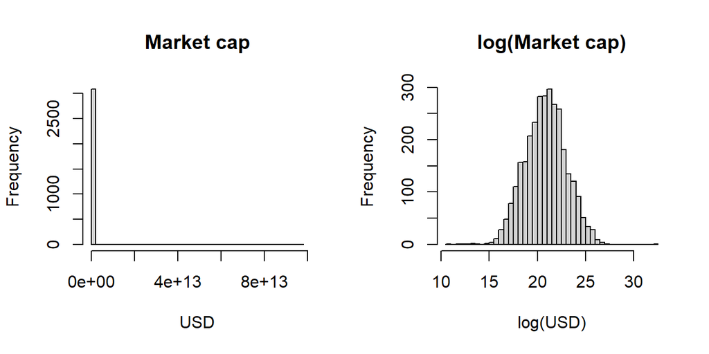

```r
par(mfrow = c(1, 2))                                 # two plots side by side
hist(fin_model$market_cap, breaks = 50, main = "Market cap", xlab = "USD")
hist(log(fin_model$market_cap), breaks = 50, main = "log(Market cap)", xlab = "log(USD)")
```

This is why financial size variables (revenue, assets, market cap) are almost always analyzed as logs in research. `log()` in R is the natural logarithm; `log10()` is base 10, as on Session 7’s plot axes. Both work; the natural log is the convention in most models.

**WarningLogs need positive values**

`log(0)` is `-Inf`, and the log of a negative number is `NaN`. That is why `fin_model` keeps only firms with positive revenue and market cap. With zeros in your data, decide (and report) how to handle them before taking logs.

# 4 The Formula Interface

Almost every modeling function in R describes the model with a **formula**: the outcome on the left of `~`, the predictors on the right. Read `~` as “is modeled by.”

| Formula | Meaning |
| --- | --- |
| `y ~ x` | `y` modeled by `x` |
| `y ~ x1 + x2` | Two predictors |
| `y ~ x1 + group` | A factor predictor: R creates dummy variables (Session 2) |
| `y ~ x1 * group` | Both predictors **and** their interaction |
| `y ~ x1 + x1:group` | Only the interaction term `x1:group`, plus `x1` |
| `log(y) ~ log(x)` | Transformations inside the formula |
| `y ~ x + I(x^2)` | Arithmetic inside `I()`, here a squared term |
| `y ~ 0 + group` | No intercept (one-hot coding, Session 2) |
| `y ~ .` | Every other column in the data |

The same formula syntax works across R, so learning it once pays off everywhere:

```r
aggregate(net_margin ~ super_sector, data = fin_model, FUN = median)   # summaries
```

```
  super_sector net_margin
1     Cyclical     0.0972
2    Defensive     0.0507
3    Sensitive     0.0436
```

```r
t.test(log(revenue) ~ price_up, data = fin_model)                      # a t-test
```

```
    Welch Two Sample t-test

data:  log(revenue) by price_up
t = 3.0218, df = 2949.2, p-value = 0.002535
alternative hypothesis: true difference in means between group Down and group Up is not equal to 0
95 percent confidence interval:
 0.08271872 0.38845539
sample estimates:
mean in group Down   mean in group Up
          20.36996           20.13438
```

You saw it in `boxplot(net_margin ~ sector, ...)` in Session 7, and you will meet it in nearly every function of your statistics course.

# 5 Linear Regression with `lm()`

## 5.1 Fitting Models

We fit three models of (log) market cap, each adding predictors. The statistics course will cover what the numbers mean; here we focus on the mechanics.

```r
m1 <- lm(log(market_cap) ~ log(revenue), data = fin_model)
m2 <- lm(log(market_cap) ~ log(revenue) + net_margin, data = fin_model)
m3 <- lm(log(market_cap) ~ log(revenue) + net_margin + super_sector, data = fin_model)

summary(m3)
```

```
Call:
lm(formula = log(market_cap) ~ log(revenue) + net_margin + super_sector,
    data = fin_model)

Residuals:
    Min      1Q  Median      3Q     Max
-8.3439 -0.6288  0.0284  0.6469 10.4763

Coefficients:
                       Estimate Std. Error t value Pr(>|t|)
(Intercept)            4.105017   0.188768  21.746  < 2e-16 ***
log(revenue)           0.821312   0.009351  87.827  < 2e-16 ***
net_margin             1.269945   0.100220  12.672  < 2e-16 ***
super_sectorDefensive  0.259259   0.059261   4.375 1.26e-05 ***
super_sectorSensitive -0.074318   0.044868  -1.656   0.0977 .
---
Signif. codes:  0 '***' 0.001 '**' 0.01 '*' 0.05 '.' 0.1 ' ' 1

Residual standard error: 1.106 on 3085 degrees of freedom
Multiple R-squared:  0.7316,    Adjusted R-squared:  0.7312
F-statistic:  2102 on 4 and 3085 DF,  p-value: < 2.2e-16
```

How to read the parts of `summary()`:

| Part | What it shows |
| --- | --- |
| `Call` | The formula and data you used: check it is the model you meant |
| `Residuals` | The spread of the differences between observed and fitted values |
| `Coefficients` | One row per term: estimate, standard error, t value, p-value |
| `super_sectorDefensive`, `super_sectorSensitive` | Dummy variables, compared with the **reference level**, `Cyclical` (Session 2) |
| `Residual standard error`, `R-squared`, `F-statistic` | How well the model fits overall |

To compare with a different reference level, change it in the data with `fct_relevel()` (Session 2) and refit.

## 5.2 Interactions

`*` adds an interaction: here, whether the relationship between revenue and market cap differs by super sector:

```r
m4 <- lm(log(market_cap) ~ log(revenue) * super_sector, data = fin_model)
coef(m4)
```

```
                       (Intercept)                       log(revenue)
                        4.15731047                         0.82684744
             super_sectorDefensive              super_sectorSensitive
                        0.83715195                        -1.22589878
log(revenue):super_sectorDefensive log(revenue):super_sectorSensitive
                       -0.03602372                         0.05017604
```

The terms with `:`, such as `log(revenue):super_sectorDefensive`, are the interaction terms.

# 6 Logistic Regression with `glm()`

When the outcome is **binary** (yes/no, up/down, adopted/not adopted), linear regression is not appropriate; **logistic regression** is the standard model. In R it is `glm()`, a “generalized linear model”, with `family = binomial`. The formula works exactly as in `lm()`.

The outcome must be coded 0/1 (or as a factor whose second level is the “success”). Here, did the stock price go up in 2015?

```r
fin_model <- fin_model |>
  mutate(up_2015 = as.integer(price_change_2015 > 0))     # 1 = went up, 0 = did not

m_logit <- glm(up_2015 ~ log(revenue) + net_margin + super_sector,
               family = binomial,
               data   = fin_model)

summary(m_logit)
```

```
Call:
glm(formula = up_2015 ~ log(revenue) + net_margin + super_sector,
    family = binomial, data = fin_model)

Coefficients:
                      Estimate Std. Error z value Pr(>|z|)
(Intercept)            1.04756    0.35010   2.992 0.002770 **
log(revenue)          -0.05811    0.01734  -3.351 0.000804 ***
net_margin             0.92008    0.18963   4.852 1.22e-06 ***
super_sectorDefensive  0.20864    0.10799   1.932 0.053350 .
super_sectorSensitive -0.45698    0.08294  -5.510 3.59e-08 ***
---
Signif. codes:  0 '***' 0.001 '**' 0.01 '*' 0.05 '.' 0.1 ' ' 1

(Dispersion parameter for binomial family taken to be 1)

    Null deviance: 4251.3  on 3089  degrees of freedom
Residual deviance: 4158.6  on 3085  degrees of freedom
AIC: 4168.6

Number of Fisher Scoring iterations: 4
```

The output looks like `lm()`’s, with a few differences: coefficients are on the **log-odds** scale, there is no R-squared, and fit is summarized by deviance and AIC. Your statistics course covers what these mean. Two lines you will use there:

```r
exp(coef(m_logit))                                          # odds ratios
```

```
          (Intercept)          log(revenue)            net_margin
            2.8506914             0.9435475             2.5094816
super_sectorDefensive super_sectorSensitive
            1.2320012             0.6331915
```

```r
predict(m_logit, type = "response") |> head()               # predicted probabilities
```

```
        1         2         3         4         5         6
0.4863977 0.5022335 0.4500482 0.4682339 0.4945241 0.4708629
```

# 7 Working with Model Objects

## 7.1 Base R Extractors

A fitted model is a list (Session 2), and functions pull out each part:

```r
coef(m2)                         # estimates
```

```
 (Intercept) log(revenue)   net_margin
   4.0941714    0.8226039    1.2331438
```

```r
confint(m2)                      # 95% confidence intervals
```

```
                 2.5 %    97.5 %
(Intercept)  3.7223437 4.4659990
log(revenue) 0.8042926 0.8409153
net_margin   1.0429937 1.4232939
```

```r
head(fitted(m2))                 # fitted values, one per firm
```

```
       1        2        3        4        5        6
24.87919 22.26989 24.93496 23.81830 23.64036 24.86227
```

```r
head(residuals(m2))              # residuals, one per firm
```

```
         1          2          3          4          5          6
 1.2053729  0.2864643 -1.3061727 -1.2450446  0.5893670  0.7051808
```

```r
nobs(m2)                         # observations used
```

```
[1] 3090
```

`predict()` applies a model to **new** data. For example, the predicted market cap of three hypothetical firms:

```r
new_firms <- tibble(revenue    = c(1e8, 1e9, 1e10),        # $100M, $1B, $10B
                    net_margin = 0.10)

predict(m2, newdata = new_firms)                    # predicted log(market cap)
```

```
       1        2        3
19.37041 21.26453 23.15864
```

```r
exp(predict(m2, newdata = new_firms))               # back to dollars
```

```
          1           2           3
  258501064  1718170582 11420108306
```

## 7.2 `broom`: Model Results as Data Frames

The base R extractors return vectors and matrices in different shapes. `broom` turns any model into a **tidy data frame**, which you can filter, sort, plot, and turn into tables with everything you have learned:

| Function | Returns | One row per |
| --- | --- | --- |
| `tidy()` | Estimates, standard errors, statistics, p-values | Term |
| `glance()` | Fit statistics: R-squared, AIC, number of observations | Model |
| `augment()` | The data plus fitted values and residuals | Observation |

```r
tidy(m3)
```

```
# A tibble: 5 × 5
  term                  estimate std.error statistic  p.value
  <chr>                    <dbl>     <dbl>     <dbl>    <dbl>
1 (Intercept)             4.11     0.189       21.7  1.13e-97
2 log(revenue)            0.821    0.00935     87.8  0
3 net_margin              1.27     0.100       12.7  6.57e-36
4 super_sectorDefensive   0.259    0.0593       4.37 1.26e- 5
5 super_sectorSensitive  -0.0743   0.0449      -1.66 9.77e- 2
```

```r
tidy(m3, conf.int = TRUE)                       # add confidence intervals
```

```
# A tibble: 5 × 7
  term                  estimate std.error statistic  p.value conf.low conf.high
  <chr>                    <dbl>     <dbl>     <dbl>    <dbl>    <dbl>     <dbl>
1 (Intercept)             4.11     0.189       21.7  1.13e-97    3.73     4.48
2 log(revenue)            0.821    0.00935     87.8  0           0.803    0.840
3 net_margin              1.27     0.100       12.7  6.57e-36    1.07     1.47
4 super_sectorDefensive   0.259    0.0593       4.37 1.26e- 5    0.143    0.375
5 super_sectorSensitive  -0.0743   0.0449      -1.66 9.77e- 2   -0.162    0.0137
```

```r
glance(m3)
```

```
# A tibble: 1 × 12
  r.squared adj.r.squared sigma statistic p.value    df logLik   AIC   BIC
      <dbl>         <dbl> <dbl>     <dbl>   <dbl> <dbl>  <dbl> <dbl> <dbl>
1     0.732         0.731  1.11     2102.       0     4 -4693. 9398. 9435.
# ℹ 3 more variables: deviance <dbl>, df.residual <int>, nobs <int>
```

```r
augment(m3) |> select(1:3, .fitted, .resid) |> head(3)
```

```
# A tibble: 3 × 5
  `log(market_cap)` `log(revenue)` net_margin .fitted  .resid
              <dbl>          <dbl>      <dbl>   <dbl>   <dbl>
1              26.1           25.0     0.156     25.1  0.962
2              22.6           22.0     0.0364    22.5  0.0435
3              23.6           25.3     0.0154    25.2 -1.54
```

```r
tidy(m_logit, exponentiate = TRUE)              # odds ratios for a logistic model
```

```
# A tibble: 5 × 5
  term                  estimate std.error statistic      p.value
  <chr>                    <dbl>     <dbl>     <dbl>        <dbl>
1 (Intercept)              2.85     0.350       2.99 0.00277
2 log(revenue)             0.944    0.0173     -3.35 0.000804
3 net_margin               2.51     0.190       4.85 0.00000122
4 super_sectorDefensive    1.23     0.108       1.93 0.0534
5 super_sectorSensitive    0.633    0.0829     -5.51 0.0000000359
```

Because the results are data frames, comparing models is ordinary data wrangling:

```r
list(m1 = m1, m2 = m2, m3 = m3) |>
  map(glance) |>                                  # one glance() per model (Session 3)
  bind_rows(.id = "model") |>                     # stack them (Session 6)
  select(model, r.squared, adj.r.squared, AIC, nobs)
```

```
# A tibble: 3 × 5
  model r.squared adj.r.squared   AIC  nobs
  <chr>     <dbl>         <dbl> <dbl> <int>
1 m1        0.715         0.714 9582.  3090
2 m2        0.729         0.729 9427.  3090
3 m3        0.732         0.731 9398.  3090
```

# 8 Tables for Papers

`knitr::kable()` turns any data frame into a formatted table, in HTML, PDF, or Word, depending on how you render the document.

## 8.1 A Descriptive Table

```r
desc_table <- fin_model |>
  group_by(super_sector) |>
  summarise(Firms             = n(),
            `Revenue ($B)`    = median(revenue) / 1e9,
            `Net margin`      = sprintf("%.3f (%.3f)", mean(net_margin), sd(net_margin)),
            `Share up 2015`   = mean(up_2015)) |>
  rename(`Super sector` = super_sector)

kable(desc_table,
      digits  = 2,
      caption = "Firm characteristics by super sector. Revenue is the median; net margin is the mean (SD).")
```

Firm characteristics by super sector. Revenue is the median; net margin is the mean (SD).

| Super sector | Firms | Revenue ($B) | Net margin | Share up 2015 |
| --- | --- | --- | --- | --- |
| Cyclical | 1377 | 0.53 | 0.129 (0.194) | 0.50 |
| Defensive | 500 | 0.79 | 0.005 (0.245) | 0.52 |
| Sensitive | 1213 | 0.71 | 0.029 (0.188) | 0.36 |

`sprintf("%.3f (%.3f)", m, s)` formats two numbers as text with three decimals, the common “mean (SD)” style.

## 8.2 A Regression Table

A regression table in a paper shows several models side by side: one column per model, one row per term, with standard errors in parentheses. We build it in three steps, with tools from Sessions 3, 5, and 6.

**Step 1: coefficients**, from `tidy()`, formatted with stars:

```r
models <- list("(1)" = m1, "(2)" = m2, "(3)" = m3)

coef_rows <- models |>
  map(tidy) |>
  bind_rows(.id = "model") |>
  mutate(stars = case_when(p.value < 0.01 ~ "***",
                           p.value < 0.05 ~ "**",
                           p.value < 0.10 ~ "*",
                           .default       = ""),
         cell  = paste0(sprintf("%.3f", estimate), stars,
                        " (", sprintf("%.3f", std.error), ")")) |>
  select(model, term, cell) |>
  pivot_wider(names_from = model, values_from = cell, values_fill = "")

coef_rows
```

```
# A tibble: 5 × 4
  term                  `(1)`              `(2)`              `(3)`
  <chr>                 <chr>              <chr>              <chr>
1 (Intercept)           "3.899*** (0.194)" "4.094*** (0.190)" 4.105*** (0.189)
2 log(revenue)          "0.836*** (0.010)" "0.823*** (0.009)" 0.821*** (0.009)
3 net_margin            ""                 "1.233*** (0.097)" 1.270*** (0.100)
4 super_sectorDefensive ""                 ""                 0.259*** (0.059)
5 super_sectorSensitive ""                 ""                 -0.074* (0.045)
```

**Step 2: fit statistics**, from `glance()`, reshaped to the same layout:

```r
fit_rows <- models |>
  map(glance) |>
  bind_rows(.id = "model") |>
  transmute(model,
            Observations = as.character(nobs),
            `R-squared`  = sprintf("%.3f", r.squared)) |>
  pivot_longer(-model, names_to = "term", values_to = "cell") |>
  pivot_wider(names_from = model, values_from = cell)
```

**Step 3: stack and display.** `kable()` with readable term names:

```r
reg_table <- bind_rows(coef_rows, fit_rows) |>
  mutate(term = case_when(term == "(Intercept)"           ~ "Intercept",
                          term == "log(revenue)"          ~ "log(Revenue)",
                          term == "net_margin"            ~ "Net margin",
                          term == "super_sectorDefensive" ~ "Defensive (vs. Cyclical)",
                          term == "super_sectorSensitive" ~ "Sensitive (vs. Cyclical)",
                          .default = term))

kable(reg_table,
      col.names = c("", "(1)", "(2)", "(3)"),
      align     = "lccc",
      caption   = "Dependent variable: log(market cap). Standard errors in parentheses. * p < 0.10, ** p < 0.05, *** p < 0.01.")
```

Dependent variable: log(market cap). Standard errors in parentheses. * p < 0.10, ** p < 0.05, *** p < 0.01.

|  | (1) | (2) | (3) |
| --- | --- | --- | --- |
| Intercept | 3.899*** (0.194) | 4.094*** (0.190) | 4.105*** (0.189) |
| log(Revenue) | 0.836*** (0.010) | 0.823*** (0.009) | 0.821*** (0.009) |
| Net margin |  | 1.233*** (0.097) | 1.270*** (0.100) |
| Defensive (vs. Cyclical) |  |  | 0.259*** (0.059) |
| Sensitive (vs. Cyclical) |  |  | -0.074* (0.045) |
| Observations | 3090 | 3090 | 3090 |
| R-squared | 0.715 | 0.729 | 0.732 |

The code is longer than one function call, but every step is something you already know, and you control every detail. Journals differ in what they want (stars or none, standard errors or t-statistics, the same line or the next): change a line or two.

**TipMany packages, one job**

Packages such as `modelsummary` and `gtsummary` produce regression and descriptive tables in one function call, with many formatting options. They are worth exploring once you know what you want your tables to look like.

## 8.3 Rendering to Word

Most journals and coauthors want Word files. Quarto renders the same document to Word by changing the format in the header:

```yaml
format: docx
```

Or keep both formats, and choose in RStudio’s **Render** menu:

```yaml
format:
  html: default
  docx: default
```

`kable()` tables become native Word tables, which you or your coauthors can edit. Figures are included automatically, and code chunks can be hidden in the output with `echo: false` under `execute:` in the header.

# 9 Capstone: From Raw File to Report

**ImportantCapstone exercise**

**Research question:** In technology and healthcare, do firms that spend more of their revenue on R&D have higher market values, for a given revenue?

Create a **new Quarto document** that answers this question from the raw file, using what you learned in every session:

1. **Import (Session 4):** read `data/finance_example.csv` and name the first column `ticker`.
2. **Select and filter (Session 5):** keep `ticker`, `Sector`, `Revenue`, `R&D Expenses`, and `Market Cap`, with `snake_case` names. Keep the Technology and Healthcare sectors.
3. **Check the data (Sessions 5 and 6):** count missing values in each column. How many firms have R&D spending **greater than** revenue? Look at a few of them: what kind of firms are they?
4. **Create variables (Session 5):** `rd_intensity = rd_expenses / revenue`. Keep firms with positive revenue and market cap and with `rd_intensity` between 0 and 1, and report how many firms you excluded and why.
5. **Plot (Session 7):** a scatter plot of market cap (log scale) against `rd_intensity`, faceted by sector, with a title that states what you see.
6. **Describe (this session):** a table by sector with the number of firms, median revenue, and median R&D intensity.
7. **Model (this session):** fit `log(market_cap) ~ log(revenue)`, then add `rd_intensity`, then add `sector`. Present the three models in a regression table.
8. **Report:** write two or three sentences answering the research question, and render the document to Word.

**TipCapstone solution (click to expand)**

```r
# 1. Import
raw <- read.csv("../data/finance_example.csv", check.names = FALSE)
names(raw)[1] <- "ticker"

# 2. Select and filter
rd <- as_tibble(raw) |>
  select(ticker,
         sector      = Sector,
         revenue     = Revenue,
         rd_expenses = `R&D Expenses`,
         market_cap  = `Market Cap`) |>
  filter(sector %in% c("Technology", "Healthcare"))

# 3. Check the data
rd |> summarise(across(everything(), \(x) sum(is.na(x))))
```

```
# A tibble: 1 × 5
  ticker sector revenue rd_expenses market_cap
   <int>  <int>   <int>       <int>      <int>
1      0      0       4           7         50
```

```r
rd |>
  filter(rd_expenses > revenue) |>
  arrange(desc(rd_expenses / revenue)) |>
  head()          # mostly healthcare firms with small revenue: early-stage biotech
```

```
# A tibble: 6 × 5
  ticker sector     revenue rd_expenses market_cap
  <chr>  <chr>        <dbl>       <dbl>      <dbl>
1 HRTX   Healthcare       0    54833000 293551796.
2 INSM   Healthcare       0    56292000 768317488.
3 AKBA   Healthcare       0    23263000 236766970.
4 AMPE   Healthcare       0    22490578 178264872.
5 VKTX   Healthcare       0    22223073  78266496
6 ESPR   Healthcare       0    25302000 822944011.
```

```r
# 4. Create variables and filter, reporting exclusions
rd_clean <- rd |>
  mutate(rd_intensity = rd_expenses / revenue) |>
  filter(revenue > 0, market_cap > 0, between(rd_intensity, 0, 1))

c(technology_and_healthcare = nrow(rd), analyzed = nrow(rd_clean),
  excluded = nrow(rd) - nrow(rd_clean))
```

```
technology_and_healthcare                  analyzed                  excluded
                     1158                       816                       342
```

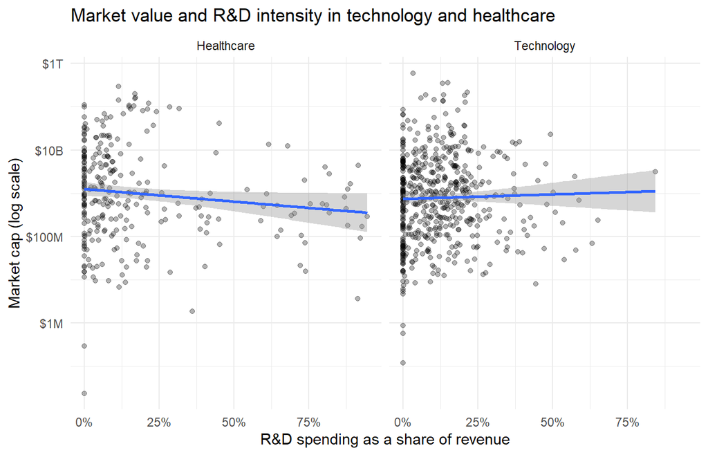

```r
# 5. Plot
ggplot(rd_clean, aes(x = rd_intensity, y = market_cap)) +
  geom_point(alpha = 0.3) +
  geom_smooth(method = "lm", formula = y ~ x) +
  scale_y_log10(labels = scales::label_dollar(scale_cut = scales::cut_short_scale())) +
  scale_x_continuous(labels = scales::label_percent()) +
  facet_wrap(~ sector) +
  labs(title = "Market value and R&D intensity in technology and healthcare",
       x = "R&D spending as a share of revenue", y = "Market cap (log scale)") +
  theme_minimal()
```

```r
# 6. Describe
rd_clean |>
  group_by(sector) |>
  summarise(Firms                 = n(),
            `Median revenue ($M)` = median(revenue) / 1e6,
            `Median R&D intensity` = median(rd_intensity)) |>
  kable(digits = 2)
```

| sector | Firms | Median revenue ($M) | Median R&D intensity |
| --- | --- | --- | --- |
| Healthcare | 280 | 284.39 | 0.08 |
| Technology | 536 | 337.07 | 0.10 |

```r
# 7. Model
rd_models <- list(
  "(1)" = lm(log(market_cap) ~ log(revenue), data = rd_clean),
  "(2)" = lm(log(market_cap) ~ log(revenue) + rd_intensity, data = rd_clean),
  "(3)" = lm(log(market_cap) ~ log(revenue) + rd_intensity + sector, data = rd_clean)
)

rd_coefs <- rd_models |>
  map(tidy) |>
  bind_rows(.id = "model") |>
  mutate(cell = paste0(sprintf("%.3f", estimate),
                       case_when(p.value < 0.01 ~ "***", p.value < 0.05 ~ "**",
                                 p.value < 0.10 ~ "*", .default = ""),
                       " (", sprintf("%.3f", std.error), ")")) |>
  select(model, term, cell) |>
  pivot_wider(names_from = model, values_from = cell, values_fill = "")

rd_fit <- rd_models |>
  map(glance) |>
  bind_rows(.id = "model") |>
  transmute(model, Observations = as.character(nobs),
            `R-squared` = sprintf("%.3f", r.squared)) |>
  pivot_longer(-model, names_to = "term", values_to = "cell") |>
  pivot_wider(names_from = model, values_from = cell)

bind_rows(rd_coefs, rd_fit) |>
  kable(col.names = c("", "(1)", "(2)", "(3)"), align = "lccc",
        caption = "Dependent variable: log(market cap). Standard errors in parentheses.")
```

Dependent variable: log(market cap). Standard errors in parentheses.

|  | (1) | (2) | (3) |
| --- | --- | --- | --- |
| (Intercept) | 3.609*** (0.395) | 1.746*** (0.392) | 1.851*** (0.399) |
| log(revenue) | 0.862*** (0.020) | 0.934*** (0.019) | 0.933*** (0.019) |
| rd_intensity |  | 3.145*** (0.254) | 3.097*** (0.256) |
| sectorTechnology |  |  | -0.123 (0.090) |
| Observations | 816 | 816 | 816 |
| R-squared | 0.697 | 0.745 | 0.746 |

The regression-table code appears twice in this session. That is the signal from Session 3: if you will make tables like this often, turn it into a function, `make_reg_table(models)`, and reuse it.

# 10 Summary

- **Describe before you model:** `summary()`, group summaries, `table()` and `prop.table()`, and `cor()` with `use = "complete.obs"` (Section 2).
- **Skewed size variables are analyzed as logs.** Extreme values can hide a strong relationship from the Pearson correlation; logs or Spearman correlation reveal it (Section 3).
- **One formula syntax everywhere:** `y ~ x1 + x2`, factors become dummies, `*` adds interactions, `log()` and `I()` transform (Section 4).
- **`lm()`** for continuous outcomes, **`glm(family = binomial)`** for binary ones (Section 5, Section 6).
- **Extract results** with `coef()`, `confint()`, `predict()`, or as data frames with `broom::tidy()`, `glance()`, and `augment()` (Section 7).
- **Tables for papers:** wrangle `broom` output with `dplyr` and `pivot_wider()`, display with `kable()`, and render to Word with `format: docx` (Section 8).

**Congratulations on finishing the workshop.** You can now take a raw data file to a cleaned dataset, figures, and tables in one reproducible document, which is the first part of every empirical paper you will write.

## 10.1 Further Reading

- [R for Data Science (2e)](https://r4ds.hadley.nz/): the best next step, cover to cover
- [broom documentation](https://broom.tidymodels.org/)
- [Quarto: Word documents](https://quarto.org/docs/output-formats/ms-word.html)